# Data Analysis Project

# Student Information

**Name**: Sahith Reddy Battapuram **G Number**: G01337411

# Introduction

This semester we will be working with a dataset of all domestic outbound flights from Dulles International Airport in 2016.

Airports depend on accurate flight departure and arrival estimates to maintain operations, profitability, customer satisfaction, and compliance with state and federal laws. Flight performance, including departure and arrival delays must be monitored, submitted to the Federal Aviation Agency (FAA) on a regular basis, and minimized to maintain airport operations. **The FAA considered a flight to be delayed if it has an arrival delay of at least 15 minutes**.

The executives at Dulles International Airport have hired you as a Data Science consultant to perform an exploratory data analysis on all domestic flights from 2016 and produce an executive summary of your key insights and recommendations to the executive team.

Before you begin, take a moment to read through the following airline flight terminology to familiarize yourself with the industry: [Airline Flight Terms](https://www.myairlineflight.com)

## Dulles Flights Data

The `flights_df` data frame is loaded below and consists of 33,433 flights from IAD (Dulles International) in 2016. The rows in this data frame represent a single flight with all of the associated features that are displayed in the table below.

**Note**: If you have not installed the `tidyverse` package, please do so by going to the `Packages` tab in the lower right section of RStudio, select the `Install` button and type `tidyverse` into the prompt. If you cannot load the data, then try downloading the latest version of R (at least 4.0). The `readRDS()` function has different behavior in older versions of `R` and may cause loading issues.

```r
library(tidyverse)

flights_df <- readRDS(url('https://gmubusinessanalytics.netlify.app/data/dulles_flights.rds'))
```

### Raw Data

```r
flights_df
```

```
# A tibble: 33,433 × 22
   scheduled_flight_date month_numeric month     day weekday airline   tail_num
   <date>                        <dbl> <fct>   <dbl> <fct>   <fct>     <fct>
 1 2016-01-01                        1 January     1 Friday  Southwest N569WN
 2 2016-01-01                        1 January     1 Friday  Southwest N466WN
 3 2016-01-01                        1 January     1 Friday  Southwest N458WN
 4 2016-01-01                        1 January     1 Friday  Southwest N922WN
 5 2016-01-01                        1 January     1 Friday  Southwest N711HK
 6 2016-01-01                        1 January     1 Friday  American  N473AA
 7 2016-01-01                        1 January     1 Friday  American  N3HUAA
 8 2016-01-01                        1 January     1 Friday  American  N564AA
 9 2016-01-01                        1 January     1 Friday  American  N4UBAA
10 2016-01-01                        1 January     1 Friday  American  N837AW
# … with 33,423 more rows, and 15 more variables: flight_num <dbl>,
#   dest_airport_name <fct>, dest_airport_city <fct>, dest_airport_state <fct>,
#   dest_airport_region <fct>, sch_dep_time <dbl>, dep_time <dbl>,
#   dep_delay <dbl>, taxi_out <dbl>, wheels_on <dbl>, taxi_in <dbl>,
#   arrival_time <dbl>, sch_arrival_time <dbl>, arrival_delay <dbl>,
#   distance <dbl>
```

# Exploratory Data Analysis

Executives at this company have hired you as a data science consultant to evaluate their flight data and make recommendations on flight operations and strategies for minimizing flight delays.

You must think of **at least 8 relevant questions** that will provide evidence for your recommendations.

The goal of your analysis should be discovering which variables drive the differences between flights that are early/on-time vs. flights that are delayed.

Some of the many questions you can explore include:

- Are flight delays affected by taxi-out time? Do certain airlines or time of year lead to greater taxi out times (i.e. traffic jams on the runways)?
- Are certain times of the day or year problematic?
- Are certain destination or airlines prone to delays?

You must answer each question and provide supporting data summaries with either a summary data frame (using `dplyr`/`tidyr`) or a plot (using `ggplot`) or both.

In total, you must have a minimum of 5 plots and 4 summary data frames for the exploratory data analysis section. Among the plots you produce, you must have at least 4 different types (ex. box plot, bar chart, histogram, heat map, etc…)

Each question must be answered with supporting evidence from your tables and plots.

## Question 1

**Question**: Are certain destination or airlines prone to delays?

**Answer**: Yes. According to the analysis, the United Airlines is more prone to delay (where it got delayed 3115 times) and when destination airport is considered, the Los Angeles airport is more prone to delay (where 730 flights got delayed). And, when Airlines and the destination airport it is going to is considered, United Airlines going to the San Francisco airport tops the list where it got delayed 541 times. But, from the boxplot it can be seen that if the two values for Unied Airlines (541 - going to San Francisco and 433 - going to Los Angeles) are considered as outliers, then the flight by United Airlines going to Denver is the one which got delayed most number of times (298).

To add additional R code chunks for your work, select `Insert` then `R` from the top of this notebook file.

```r
airlines_delay <- flights_df %>%
  filter(arrival_delay >= 15) %>%
  group_by(airline) %>%
  summarise(n_flights_delayed = n()) %>%
  arrange(desc(n_flights_delayed))

airlines_delay
```

```
# A tibble: 10 × 2
   airline        n_flights_delayed
   <fct>                      <int>
 1 United                      3115
 2 American                     538
 3 JetBlue                      365
 4 Delta                        330
 5 Southwest                    288
 6 Virgin America               285
 7 Frontier                     167
 8 ExpressJet                    72
 9 SkyWest                       55
10 Alaska                        43
```

```r
destination_delay <- flights_df %>%
  filter(arrival_delay >= 15) %>%
  group_by(dest_airport_name) %>%
  summarise(flights_delayed = n()) %>%
  arrange(desc(flights_delayed))

destination_delay
```

```
# A tibble: 32 × 2
   dest_airport_name            flights_delayed
   <fct>                                  <int>
 1 Los Angeles                              730
 2 San Francisco                            709
 3 Denver                                   449
 4 Hartsfield-Jackson Atlanta               421
 5 Logan                                    340
 6 Chicago OHare                            283
 7 Orlando                                  282
 8 Dallas-Fort Worth                        259
 9 John F Kennedy                           190
10 George Bush Intercontinental             181
# … with 22 more rows
```

```r
delay_flights_dest <- flights_df %>%
  filter(arrival_delay >= 15) %>%
  group_by(airline, dest_airport_name) %>%
  summarise(delayed_flights = n()) %>%
  arrange(desc(delayed_flights))

delay_flights_dest
```

```
# A tibble: 54 × 3
# Groups:   airline [10]
   airline  dest_airport_name            delayed_flights
   <fct>    <fct>                                  <int>
 1 United   San Francisco                            541
 2 United   Los Angeles                              433
 3 United   Denver                                   298
 4 Delta    Hartsfield-Jackson Atlanta               286
 5 United   Chicago OHare                            267
 6 American Dallas-Fort Worth                        227
 7 JetBlue  John F Kennedy                           190
 8 United   George Bush Intercontinental             181
 9 American Los Angeles                              180
10 United   Orlando                                  175
# … with 44 more rows
```

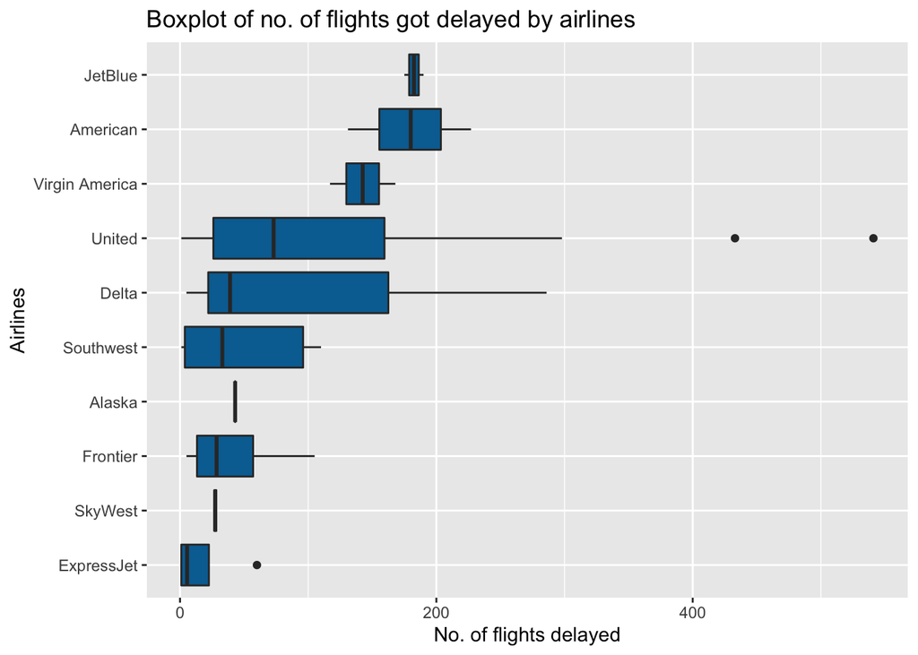

```r
ggplot(data = delay_flights_dest,
       mapping = aes(x = delayed_flights,
                     y = reorder(airline, delayed_flights))) +
  geom_boxplot(fill = "#006EA1") +
  labs(title = "Boxplot of no. of flights got delayed by airlines",
       x = "No. of flights delayed",
       y = "Airlines")
```

## Question 2

**Question**: Are certain times of the day or year problematic?

**Answer**: Yes. Based on the analysis done, July and June tops the list in which most number of flights got delayed (748 and 682 respectively). It may be due to the summer season where people travel more as this being a holiday season. Also, bad weather conditions like summer thunderstorms and fog sometimes can affect the flight journey.

```r
delay_flights_month <- flights_df %>%
  filter(arrival_delay >= 15) %>%
  group_by(month) %>%
  summarise(delayed_flights_mnth = n()) %>%
  arrange(desc(delayed_flights_mnth))

delay_flights_month
```

```
# A tibble: 12 × 2
   month     delayed_flights_mnth
   <fct>                    <int>
 1 July                       748
 2 June                       682
 3 December                   670
 4 August                     550
 5 October                    403
 6 May                        401
 7 September                  380
 8 March                      328
 9 April                      324
10 February                   269
11 November                   268
12 January                    235
```

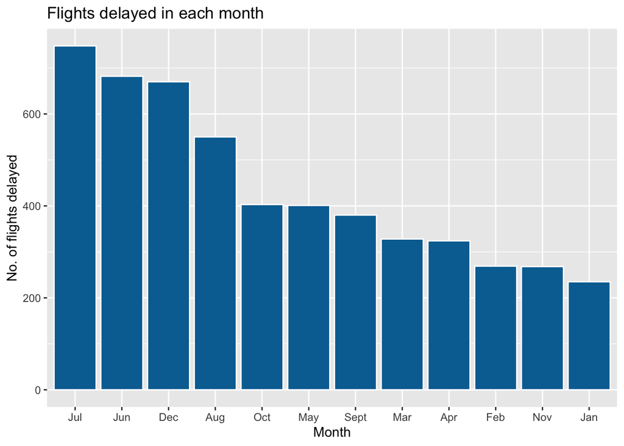

```r
ggplot(data = delay_flights_month, mapping = aes(x = reorder(month, -delayed_flights_mnth),
                                                 y = delayed_flights_mnth)) +
  geom_bar(stat = "identity", fill = "#006EA1", color = "white") +
  labs(title = "Flights delayed in each month",
       x = "Month",
       y = "No. of flights delayed") +
  scale_x_discrete(labels = c("January" = "Jan", "February" = "Feb", "March" = "Mar", "April" = "Apr",
                              "May" = "May", "June" = "Jun", "July" = "Jul", "August" = "Aug",
                              "September" = "Sept", "October" = "Oct", "November" = "Nov",
                              "December" = "Dec"))
```

## Question 3

**Question**: Are flight delays of a particular airlines affected by taxi-out time?

**Answer**: Yes. Totaling the values of taxi_out for a particular airline gives the total time taken by the airline (which is the total sum of observations given in the data) to go to the runway from the gate, and comparing this to the total no. of flights delayed of that particular airline, it can be said that the taxi_out time has affect on the flight delays.

```r
delay_flights_to <- flights_df %>%
  filter(arrival_delay >= 15) %>%
  group_by(airline) %>%
  summarise(sum_to = sum(taxi_out),
            avg_delay = mean(arrival_delay),
            delay_count = n()) %>%
  arrange(desc(sum_to))

delay_flights_to
```

```
# A tibble: 10 × 4
   airline        sum_to avg_delay delay_count
   <fct>           <dbl>     <dbl>       <int>
 1 United          82287      69.6        3115
 2 American        13802      74.1         538
 3 JetBlue          9965      73.2         365
 4 Delta            8774      79.7         330
 5 Southwest        7759      60.3         288
 6 Virgin America   6334      58.3         285
 7 Frontier         4470      85.7         167
 8 SkyWest          2156     116.           55
 9 ExpressJet       2006      82.3          72
10 Alaska           1300      61.8          43
```

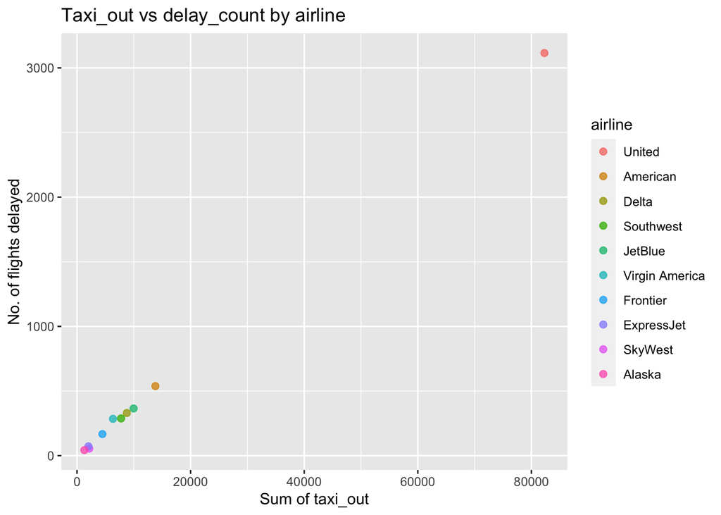

```r
ggplot(data = delay_flights_to, mapping = aes(x = sum_to, y = delay_count, color = airline)) +
  geom_point(size = 2, alpha = 0.75) +
  labs(title = "Taxi_out vs delay_count by airline",
       x = "Sum of taxi_out",
       y = "No. of flights delayed")
```

## Question 4

**Question**: Do certain time of year lead to greater taxi out times (i.e., traffic jams on the runways)?

**Answer**: From the analysis, the taxi out time spent by an airline is more in June and July. Also, the average delay in these months is high when compared with other months. So, from this it can be observed that the summer season in the year leads to greater taxi out times.

```r
delay_month_high_to <- flights_df %>%
  filter(arrival_delay >= 15) %>%
  group_by(month) %>%
  summarise(max_to = max(taxi_out),
            avg_delay = mean(arrival_delay),
            delay_count = n()) %>%
  arrange(desc(max_to))

delay_month_high_to
```

```
# A tibble: 12 × 4
   month     max_to avg_delay delay_count
   <fct>      <dbl>     <dbl>       <int>
 1 June         159      88.4         682
 2 July         157      84.2         748
 3 August       151      68.5         550
 4 May          150      57.9         401
 5 April        147      67.2         324
 6 October      140      63.0         403
 7 November     120      69.1         268
 8 September    119      64.6         380
 9 February     118      74.0         269
10 January      114      64.2         235
11 March        108      65.1         328
12 December      98      63.3         670
```

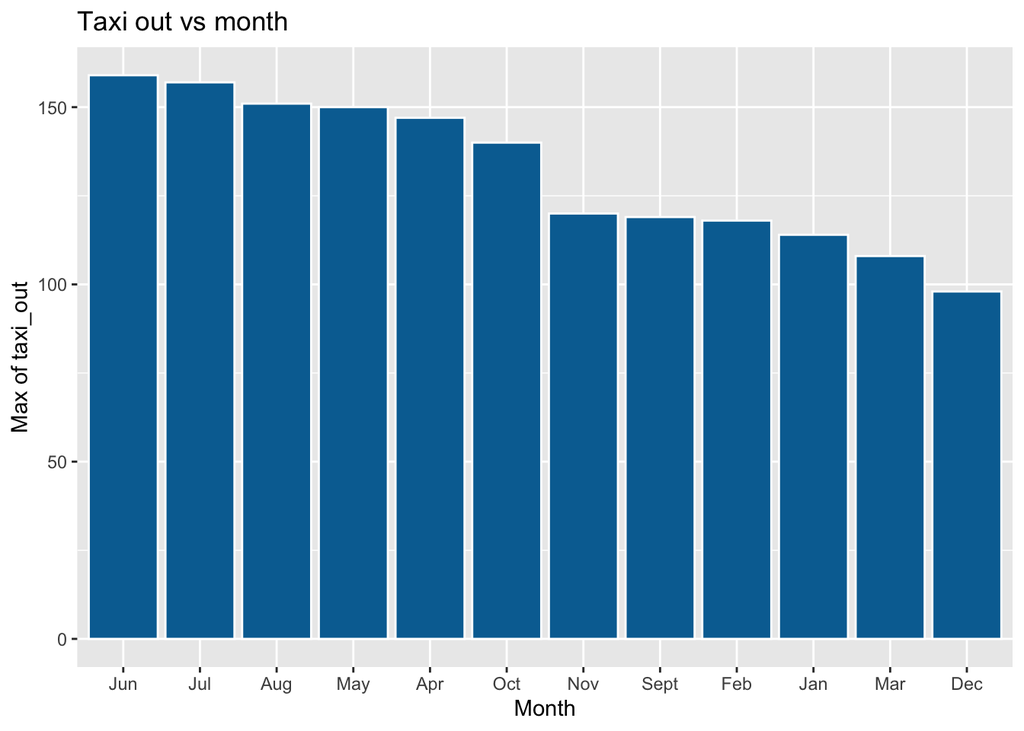

```r
ggplot(data = delay_month_high_to, mapping = aes(x = reorder(month, -max_to),
                                                 y = max_to)) +
  geom_bar(stat = "identity", fill = "#006EA1", color = "white") +
  labs(title = "Taxi out vs month",
       x = "Month",
       y = "Max of taxi_out") +
  scale_x_discrete(labels = c("January" = "Jan", "February" = "Feb", "March" = "Mar", "April" = "Apr",
                              "May" = "May", "June" = "Jun", "July" = "Jul", "August" = "Aug",
                              "September" = "Sept", "October" = "Oct", "November" = "Nov",
                              "December" = "Dec"))
```

## Question 5

**Question**: How Departure delays and arrival delays by certain airlines are related?

**Answer**: From this analysis, it can be observed that even though the number of flights delayed at departure are more for each airline, the number of flights delayed at arrival are less.

```r
dept_delay  <- flights_df %>%
  filter(dep_delay > 0) %>%
  group_by(airline) %>%
  summarise(delay_dept = n()) %>%
  arrange(desc(delay_dept))

dept_delay
```

```
# A tibble: 10 × 2
   airline        delay_dept
   <fct>               <int>
 1 United               6895
 2 American              915
 3 Delta                 646
 4 Southwest             594
 5 Virgin America        568
 6 JetBlue               554
 7 Frontier              215
 8 Alaska                122
 9 ExpressJet            108
10 SkyWest               103
```

```r
arr_dept_airline <- cbind(dept_delay, airlines_delay)
arr_dept <- arr_dept_airline %>% select(-3)
arr_dept
```

```
          airline delay_dept n_flights_delayed
1          United       6895              3115
2        American        915               538
3           Delta        646               365
4       Southwest        594               330
5  Virgin America        568               288
6         JetBlue        554               285
7        Frontier        215               167
8          Alaska        122                72
9      ExpressJet        108                55
10        SkyWest        103                43
```

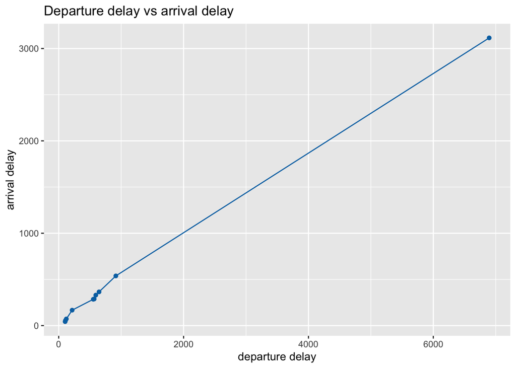

```r
ggplot(data = arr_dept, mapping = aes(x = delay_dept, y = n_flights_delayed)) +
  geom_line(color = "#0072B2") +
  geom_point(color = "#0072B2") +
  labs(title = "Departure delay vs arrival delay",
            x = "departure delay",
            y = "arrival delay")
```

## Question 6

**Question**: Does the weekday has any effect on delays and taxi in time?

**Answer**: Yes. Thursday, monday and friday are the top 3 days with most number of delayed flights. It may be due to the weekend getaway.

```r
weekday_delay <- flights_df %>%
  filter(arrival_delay >= 15) %>%
  group_by(weekday) %>%
  summarise(avg_ti = mean(taxi_in),
    delay_count = n()) %>%
  arrange(desc(delay_count))

weekday_delay
```

```
# A tibble: 7 × 3
  weekday   avg_ti delay_count
  <fct>      <dbl>       <int>
1 Thursday    10.6         893
2 Monday      11.0         811
3 Friday      11.8         803
4 Wednesday   10.5         733
5 Tuesday     11.2         730
6 Sunday      11.5         710
7 Saturday    10.9         578
```

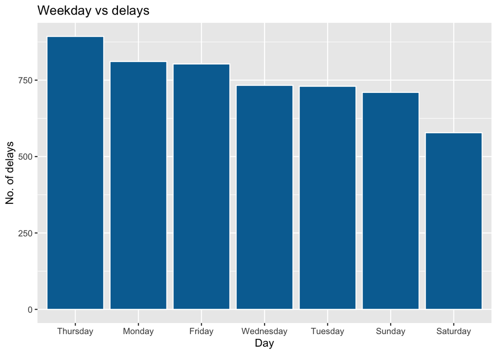

```r
ggplot(data = weekday_delay, mapping = aes(x = reorder(weekday, -delay_count),
                                                 y = delay_count)) +
  geom_bar(stat = "identity", fill = "#006EA1", color = "white") +
  labs(title = "Weekday vs delays",
       x = "Day",
       y = "No. of delays")
```

## Question 7

**Question**: Which flight number got delayed the most?

**Answer**: As said earlier, United airlines got delayed the most number of times. The flight number 1972 of United airlines is the one which got delayed many times.

```r
flightnum_delay <- flights_df %>%
  filter(arrival_delay >= 15) %>%
  group_by(flight_num, airline) %>%
  summarise(delay_count = n()) %>%
  arrange(desc(delay_count))

flightnum_delay
```

```
# A tibble: 383 × 3
# Groups:   flight_num [368]
   flight_num airline        delay_count
        <dbl> <fct>                <int>
 1       1972 United                 127
 2        340 United                 106
 3       1808 JetBlue                105
 4        719 United                  92
 5         77 Virgin America          91
 6         97 Virgin America          89
 7        356 JetBlue                 89
 8        511 United                  87
 9        822 United                  85
10       2536 American                81
# … with 373 more rows
```

## Question 8

**Question**: Does the destination airport region has any effect on flights delayed?

**Answer**: Yes. Flights heading to West are getting delayed most number of times.

```r
dest_regn <- flights_df %>%
  filter(arrival_delay >= 15) %>%
  group_by(dest_airport_region) %>%
  summarise(delay_count = n()) %>%
  arrange(desc(delay_count))

dest_regn
```

```
# A tibble: 6 × 2
  dest_airport_region delay_count
  <fct>                     <int>
1 West                       2420
2 South                      1104
3 Northeast                   742
4 Southwest                   516
5 Midwest                     462
6 Middle Atlantic              14
```

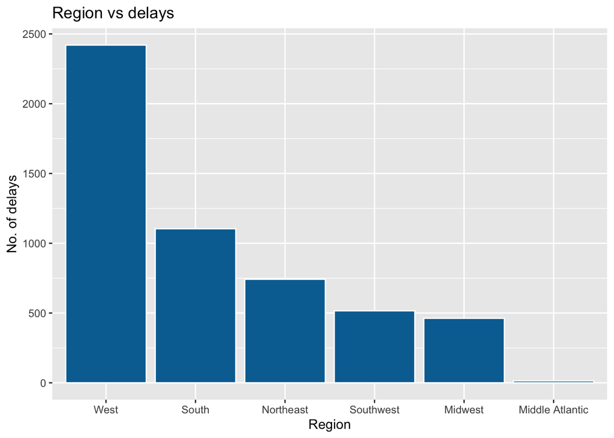

```r
ggplot(data = dest_regn, mapping = aes(x = reorder(dest_airport_region, -delay_count),
                                                 y = delay_count)) +
  geom_bar(stat = "identity", fill = "#006EA1", color = "white") +
  labs(title = "Region vs delays",
       x = "Region",
       y = "No. of delays")
```

# Summary of Results

Write an executive summary of your overall findings and recommendations to the executives at Dulles Airport. Think of this section as your closing remarks of a presentation, where you summarize your key findings and make recommendations on flight operations and strategies for minimizing flight delays.

Your executive summary must be written in a [professional tone](https://www.universalclass.com/articles/writing/business-writing/appropriate-tone-in-business-communications.htm), with minimal grammatical errors, and should include the following sections:

1. An introduction where you explain the business problem and goals of your data analysis
   - What problem(s) is this company trying to solve? Why are they important to their future success?
   - What was the goal of your analysis? What questions were you trying to answer and why do they matter?
2. Highlights and key findings from your Exploratory Data Analysis section
   - What were the interesting findings from your analysis and **why are they important for the business**?
   - This section is meant to **establish the need for your recommendations** in the following section
3. Your recommendations to the company
   - Each recommendation must be supported by your data analysis results
   - You must clearly explain **why** you are making each recommendation and which results from your data analysis support this recommendation
   - You must also describe the potential business impact of your recommendation:
     - Why is this a good recommendation?
     - What benefits will the business achieve?

## Executive Summary

Please write your executive summary below. If you prefer, you can type your summary in a text editor, such as Microsoft Word, and paste your final text here.

> Airports must accurately monitor flight departure and arrival estimates in order to maintain good operations, profitability and customer satisfaction. In the given dataset, there are many causes which can alter the estimates of flight arrivals and departures and further which effects the airport operations and profitability. It should focus more on these factors so that the operations run smoothly and efficiently.

> The goal of my analysis is to analyse which factors are affecting the flight delays so that the airport staff can be prepared in advanced to resolve these issues.

> The questions which I tried to answer in my analysis are:

```
>> Are certain destination or airlines prone to delays?
>> Are certain times of the day or year problematic?
>> Are flight delays of a particular airlines affected by taxi-out time?
>> Do certain time of year lead to greater taxi out times (i.e., traffic jams on the runways)?
>> How Departure delays and arrival delays by certain airlines are related?
>> Does the weekday has any effect on delays and taxi in time?
>> Which flight number got delayed the most?
>> Does the destination airport region has any effect on flights delayed?

>> These are important to know because the airports can further process these issues and increase their profitability and customer satisfaction.
```

> Key findings from my analysis are:

[output not shown]

> Recommendations to the company:

[output not shown]